# Forth Day Multi Omics

Mark davids

15 November, 2024

```r
library(vegan)
library(phyloseq)
library(ggplot2)
library(microbiome)
library(ggpubr)
library(tidyverse)
library(mixOmics)
```

# Multi Omics

Here we will explore two methods for “multiomics” analysis. The dataset used are baseline samples from the MPS study, which is composed of healthy FMT donors and the metSyn patients. The two omics datasets are fecal microbiome composition and fasted plasma metabolomics.

During the first analysis we will test if distance matrix of each of the two datasets have similar structures. The second analysis consists of a Regularized Canonical Correlation Analysis with which we will try to identify between datasets relation ships.

# Load and subset to equal datasets

```r
MPS.metabs <- readRDS("MPS.metabs.RDS")
taxa_names(MPS.metabs) <- MPS.metabs@tax_table[,"BIOCHEMICAL"]

MPS.16S <- readRDS("MPS.16S.triads.mod.RDS")
MPS.16S <- prune_samples(MPS.16S@sam_data$Sample_Type!="PostFMT", MPS.16S)
MPS.16S@sam_data$Subject_ID %in% sample_names(MPS.metabs)
```

```
##  [1] TRUE TRUE TRUE TRUE TRUE TRUE TRUE TRUE TRUE TRUE TRUE TRUE TRUE TRUE TRUE
## [16] TRUE TRUE TRUE TRUE TRUE TRUE TRUE TRUE TRUE TRUE TRUE TRUE TRUE TRUE TRUE
## [31] TRUE TRUE TRUE TRUE TRUE TRUE TRUE TRUE TRUE TRUE TRUE TRUE TRUE TRUE
```

```r
sample_names(MPS.16S) <- MPS.16S@sam_data$Subject_ID
taxa_names(MPS.16S) <- make.unique(paste(MPS.16S@tax_table[,6]))
```

# Reorder phyloseq so they are in the same order

```r
sample_names(MPS.16S) == sample_names(MPS.metabs)
```

```
##  [1] FALSE FALSE FALSE FALSE FALSE FALSE FALSE FALSE FALSE FALSE FALSE FALSE
## [13] FALSE FALSE FALSE FALSE FALSE FALSE FALSE FALSE FALSE FALSE FALSE FALSE
## [25] FALSE FALSE FALSE FALSE FALSE FALSE FALSE FALSE FALSE FALSE FALSE FALSE
## [37] FALSE FALSE FALSE FALSE FALSE FALSE FALSE FALSE
```

```r
MPS.metabs <- phyloseq(MPS.metabs@otu_table[, sample_names(MPS.16S)],
                       tax_table(MPS.metabs))

sample_names(MPS.16S) == sample_names(MPS.metabs)
```

```
##  [1] TRUE TRUE TRUE TRUE TRUE TRUE TRUE TRUE TRUE TRUE TRUE TRUE TRUE TRUE TRUE
## [16] TRUE TRUE TRUE TRUE TRUE TRUE TRUE TRUE TRUE TRUE TRUE TRUE TRUE TRUE TRUE
## [31] TRUE TRUE TRUE TRUE TRUE TRUE TRUE TRUE TRUE TRUE TRUE TRUE TRUE TRUE
```

```r
sample_data(MPS.metabs) <- sample_data(MPS.16S)
```

In order to reduce dimensions a bit we will aggregate microbiome data on Genus level. We are also not interested in Xenobiotics from the metabolomics panel.

```r
MPS.16S <- microbiome::aggregate_taxa(MPS.16S, "Genus")
MPS.metabs <- prune_taxa(!MPS.metabs@tax_table[,"SUPER PATHWAY"] %in% "Xenobiotics" , MPS.metabs)
```

For the CCA it is better to reduce the number of features. We will reduce it by only selecting 100 features with the highest variability.

```r
nfeat=100
asvs <- apply(microbiome::transform(MPS.16S, "Z")@otu_table@.Data,1,function(x) sum(abs(x))) %>% sort(decreasing = T) %>% head(nfeat) %>% names()

MPS.16S.reduced <- prune_taxa(asvs, MPS.16S)

metabs <- apply(microbiome::transform(MPS.metabs, "Z")@otu_table@.Data,1,function(x) sum(abs(x))) %>% sort(decreasing = T) %>% head(nfeat) %>% names()

MPS.metabs.reduced <- prune_taxa(metabs, MPS.metabs)
```

# Regular ordination

First we have a look at the datasets individually.

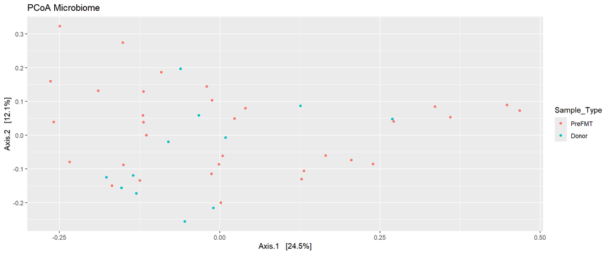

```r
plot_ordination(physeq = MPS.16S.reduced, ordination = ordinate(MPS.16S.reduced, "PCoA", "bray"), color="Sample_Type") +
  labs(title="PCoA Microbiome")
```

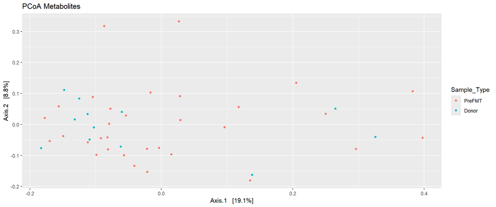

```r
plot_ordination(physeq = MPS.metabs.reduced, ordination = ordinate(MPS.metabs.reduced, "PCoA", "bray"), color="Sample_Type") +
  labs(title="PCoA Metabolites")
```

```r
d <- phyloseq::distance(physeq = MPS.16S, "bray")
adonis2(d~MPS.16S@sam_data$Sample_Type)
```

```
## Permutation test for adonis under reduced model
## Terms added sequentially (first to last)
## Permutation: free
## Number of permutations: 999
##
## adonis2(formula = d ~ MPS.16S@sam_data$Sample_Type)
##                              Df SumOfSqs      R2      F Pr(>F)
## MPS.16S@sam_data$Sample_Type  1   0.1732 0.03839 1.6768  0.069 .
## Residual                     42   4.3394 0.96161
## Total                        43   4.5127 1.00000
## ---
## Signif. codes:  0 '***' 0.001 '**' 0.01 '*' 0.05 '.' 0.1 ' ' 1
```

```r
d <- phyloseq::distance(physeq = MPS.metabs, "bray")
adonis2(d~MPS.metabs@sam_data$Sample_Type)
```

```
## Permutation test for adonis under reduced model
## Terms added sequentially (first to last)
## Permutation: free
## Number of permutations: 999
##
## adonis2(formula = d ~ MPS.metabs@sam_data$Sample_Type)
##                                 Df SumOfSqs     R2      F Pr(>F)
## MPS.metabs@sam_data$Sample_Type  1  0.13204 0.0672 3.0257  0.001 ***
## Residual                        42  1.83292 0.9328
## Total                           43  1.96497 1.0000
## ---
## Signif. codes:  0 '***' 0.001 '**' 0.01 '*' 0.05 '.' 0.1 ' ' 1
```

Not obvious from the ordination, but there is a significant difference in plasma metabolites between healthy donors and metsyn subjects.

# Procrustes

We will use procrustes to test coherence between the two datasets. In order to run procrustes we will need ordinations of the dataset. For 16S we use default Bray-Curtis distance. For metabolites we will use regular euclidean distance. For both sets we will use PCoA for ordination.

To test the probability of getting a better fit, we will perform the protest permutation test.

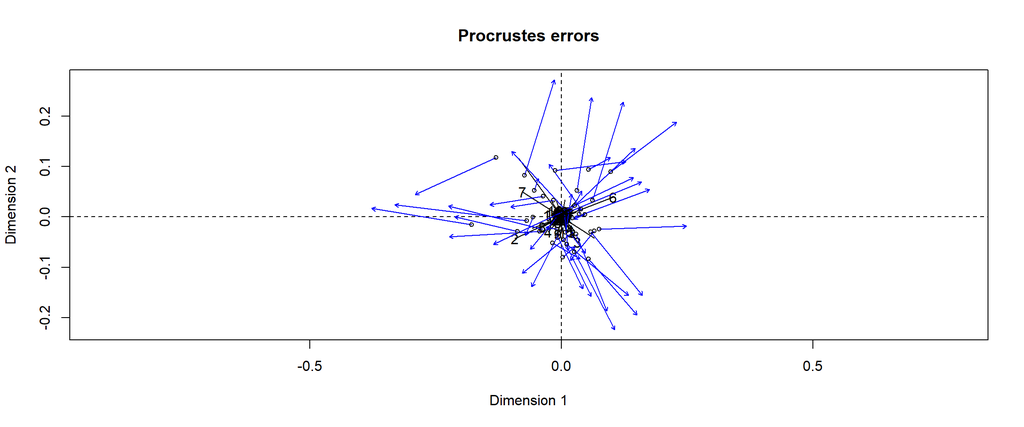

```r
ord.16S <- ordinate(MPS.16S, "PCoA", "bray")
#ord.metabs <- ordinate(microbiome::transform(MPS.metabs, "clr"), "PCoA", "euclidean")
ord.metabs <- ordinate(MPS.metabs, "PCoA", "euclidean")

plot(procrustes(X = ord.16S$vectors, Y = ord.metabs$vectors, scale=T))
```

```r
protest(X = ord.16S$vectors, Y = ord.metabs$vectors, permutations = 99999)
```

```
##
## Call:
## protest(X = ord.16S$vectors, Y = ord.metabs$vectors, permutations = 99999)
##
## Procrustes Sum of Squares (m12 squared):        0.5193
## Correlation in a symmetric Procrustes rotation: 0.6933
## Significance:  8e-05
##
## Permutation: free
## Number of permutations: 99999
```

These results show a significant relation between microbiome composition and circulating metabolites.

# rCCA

CCA is dimensionality reduction approach by maximizing the correlation of the features between the datasets. Variance in the data that is not coherent between both datasets is thereby reduced.

We will apply a regularized form of CCA, which is required if you want to perform CCA on datasets with a higher number of features than samples.

```r
X <- t(MPS.16S.reduced@otu_table@.Data)
Y <- t(MPS.metabs.reduced@otu_table@.Data)
```

# perform the CCA

There are two regularisation methods available. Here we apply the shrinkage method as feature counts are substantially larger than the number of samples.

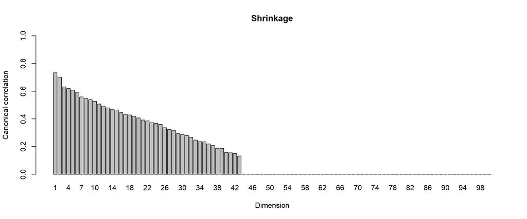

```r
rcc.MPS <- rcc(X,Y, method = 'shrinkage')
# examine the optimal lambda values after shrinkage
plot(rcc.MPS, type = "barplot", main = "Shrinkage")
```

The scree plot shows that there is a small drop off after two components indicating these two components capture more variance than by chance.

We can plot the samples in this CCA ordination.

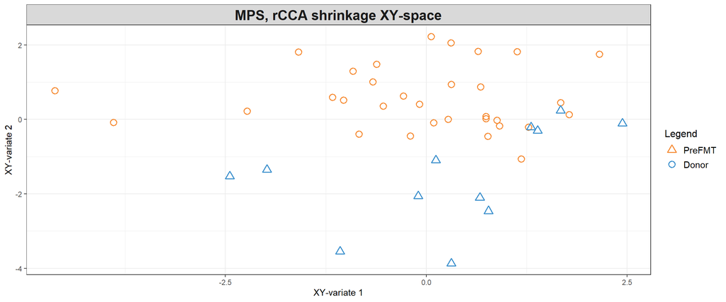

```r
plotIndiv(rcc.MPS, comp = 1:2,
          ind.names = NULL,
          group = MPS.16S@sam_data$Sample_Type, rep.space = "XY-variate",
          legend = TRUE, title = 'MPS, rCCA shrinkage XY-space')
```

This plot shows that if we focus only on coherent variance between the dataset, out healthy donor samples separate from preFMT samples.  
This implies there is a relation between fecal microbiome, plasma metabolites and health status (or other confounding factor)

We can plot the projection of both datasets, similar to the procrustus plot.

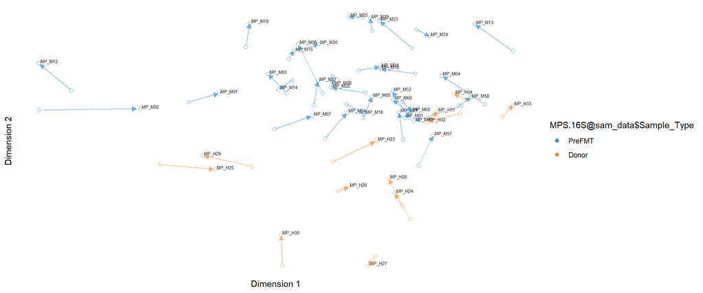

```r
plotArrow(rcc.MPS, group = MPS.16S@sam_data$Sample_Type,
          col.per.group = color.mixo(1:5),
          title = '(b) Nutrimouse, shrinkage method')
```

Besides the relations between the samples, we can also use CCA to find correlations between the datasets from the feature perspective. We can use either a circle plot, or a heatmap to visualize the correlations between the feature sets.

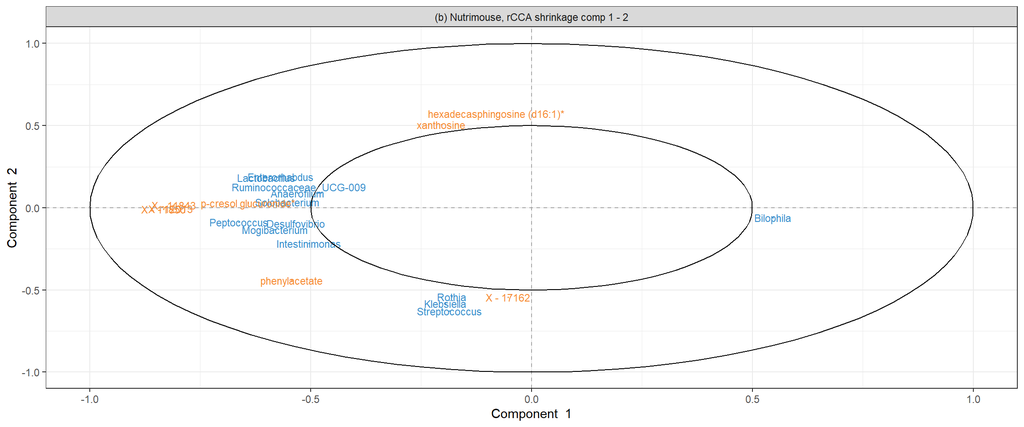

```r
plotVar(rcc.MPS, var.names = c(TRUE, TRUE),
        cex = c(3, 3), cutoff = 0.5,
        title = '(b) Nutrimouse, rCCA shrinkage comp 1 - 2')
```

```r
cim(rcc.MPS, comp = 1:2, xlab = "metabolites", ylab = "taxa")
```

[output not shown]

A difference between groups was not obvious from the unconstrained ordinations but now using a constrained approach shows there are interactions between omics datasets that seperate our groups. Some correlations between metabolites and microbes have also been identified, through the correlations are not very strong.